# Clustering a small CosMx dataset with Insitutype

### Installation

```r
# TBD
```

### Overview

This vignette demonstrates the use of the insitutype algorithm to cluster [CosMx](https://www.nature.com/articles/s41587-022-01483-z) data. CosMx is a spatial molecular imager for sub-cellular resolution of mRNA transcripts and protein targets. We analyze a subset of the [CosMx NSCLC showcase dataset](https://nanostring.com/cosmx-dataset).

### Data preparation

First, we load the package and access the example data:

```r
library(InSituType)
data("ioprofiles")
data("iocolors")
data("mini_nsclc")
str(mini_nsclc)
```

```
#> List of 5
#>  $ counts: num [1:2198, 1:960] 0 0 0 0 0 0 0 0 0 0 ...
#>   ..- attr(*, "dimnames")=List of 2
#>   .. ..$ : chr [1:2198] "c_3_18_2" "c_3_18_3" "c_3_18_4" "c_3_18_5" ...
#>   .. ..$ : chr [1:960] "AATK" "ABL1" "ABL2" "ACE" ...
#>  $ neg   : num [1:2198, 1:20] 0 0 0 0 0 0 0 0 0 0 ...
#>   ..- attr(*, "dimnames")=List of 2
#>   .. ..$ : chr [1:2198] "c_3_18_2" "c_3_18_3" "c_3_18_4" "c_3_18_5" ...
#>   .. ..$ : chr [1:20] "NegPrb3" "NegPrb6" "NegPrb15" "NegPrb18" ...
#>  $ x     : num [1:2198] 7.34 7.4 7.42 7.46 7.53 ...
#>  $ y     : num [1:2198] -6.5 -6.5 -6.5 -6.5 -6.5 ...
#>  $ umap  : num [1:2198, 1:2] 1.489 -0.774 -1.915 1.927 1.135 ...
#>   ..- attr(*, "dimnames")=List of 2
#>   .. ..$ : chr [1:2198] "c_3_18_2" "c_3_18_3" "c_3_18_4" "c_3_18_5" ...
#>   .. ..$ : NULL
```

```r
set.seed(0)
```

#### Necessary inputs

First, let us look at the data we need. 1. A matrix of counts data, cells x genes:

```r
counts <- mini_nsclc$counts
str(counts)
```

```
#>  num [1:2198, 1:960] 0 0 0 0 0 0 0 0 0 0 ...
#>  - attr(*, "dimnames")=List of 2
#>   ..$ : chr [1:2198] "c_3_18_2" "c_3_18_3" "c_3_18_4" "c_3_18_5" ...
#>   ..$ : chr [1:960] "AATK" "ABL1" "ABL2" "ACE" ...
```

```r
counts[25:30, 9:14]
```

```
#>           ACTA2 ACTG2 ACVR1 ACVR1B ACVR2A ACVRL1
#> c_3_18_39     0     0     0      0      0      0
#> c_3_18_40     0     0     0      0      0      0
#> c_3_18_41     1     0     1      0      0      0
#> c_3_18_45     2     0     0      0      0      0
#> c_3_18_46     0     0     0      0      0      0
#> c_3_18_47     0     0     0      0      0      0
```

2. A vector giving each cell mean negative control value:

```r
negmean <- Matrix::rowMeans(mini_nsclc$neg)
head(negmean)
```

```
#> c_3_18_2 c_3_18_3 c_3_18_4 c_3_18_5 c_3_18_6 c_3_18_7
#>     0.00     0.00     0.00     0.05     0.00     0.00
```

Cohort definition is left to the user, and many approaches are reasonable. For example, you might:

- Define cohort by gating cells immunofluorescence stains, e.g. PanCK+/- or CD45+/-
- Cluster cells on their continuous immunofluorescence values
- Use an autoencoder to extract features from cells images, then cluster on those features.
- Use the results of spatial clustering / “niches” to define cohorts
- Cluster on information from multiple data types together, such as the average gene expression profile of cell neighbors AND immunofluorescence.

Cohorting is a low-risk undertaking, so it is recommended whenever possible. A poorly-defined cohort will simply be uninformative; it will not send the clustering algorithm astray. The more cohorts you can define, and the higher-quality those cohorts, the more information Insitutype will be able to gleam from the alternative data types.

One warning: **do not define cohorts based on variables you want to study.** For example, if you wish to study how cell populations shift across spatial context, then spatial context must not be allowed to inform cell typing. To do so would introduce circularity.

In the below example, we will define cohorts using the “fastCohorting” function. This function is provided as a convenient way to derive cohorts from diverse data types; it makes no claim to being optimal.

```r
# simulate immunofluorescence data:
immunofluordata <- matrix(rpois(n = nrow(counts) * 4, lambda = 100),
                          nrow(counts))
# perform automatic cohorting:
cohort <- fastCohorting(immunofluordata,
                        gaussian_transform = TRUE)
# ("Gaussian_transform = TRUE" maps variables to gaussians in order to
#  place dramatically different variables on the same scale.)
table(cohort)
```

```
#> cohort
#>    1    2    3
#> 1236  631  331
```

### Unsupervised clustering:

The below command performs unsupervised clustering. We will let the algorithm try to select the optimal number of clusters from a range of plausible options using the n_clusts argument.

Note: this should take a few minutes on a standard laptop.

```r
unsup <- insitutype(
  x = counts,
  neg = negmean,
  cohort = cohort,
  # Enter your own per-cell background estimates here if you have them;
  # otherwise insitutype will use the negprobes to estimate background for you.
  bg = NULL,
  # condensed to save time. n_clusts = 5:20 would be more optimal
  n_clusts = c(10, 12),
  # NULL value runs unsupervised clustering; entering a matrix here would run
  # semi-supervised clustering.
  reference_profiles = NULL,
  n_phase1 = 200,
  n_phase2 = 500,
  n_phase3 = 2000,
  n_starts = 1,
  max_iters = 5
) # choosing inadvisably low numbers to speed the vignette; using the defaults in recommended.
```

```
#> 6.74 cells per geometric bin.
#> Selecting optimal number of clusters from a range of 10 - 12
#> Clustering with n_clust = 10
#> iter 1
#> iter 2
#> iter 3
#> iter 4
#> iter 5
#> iter 6
#> iter 7
#> iter 8
#> iter 9
#> iter 10
#> Converged: <= 0.5% of cell type assignments changed in the last iteration.
#> ==========================================================================
#> Clustering with n_clust = 12
#> iter 1
#> iter 2
#> iter 3
#> iter 4
#> iter 5
#> iter 6
#> iter 7
#> iter 8
#> iter 9
#> iter 10
#> Converged: <= 0.5% of cell type assignments changed in the last iteration.
#> ==========================================================================
#> phase 1: random starts in 200 cell subsets
#> iter 1
#> iter 2
#> iter 3
#> Converged: <= 0.2% of cell type assignments changed in the last iteration.
#> ==========================================================================
#> phase 2: refining best random start in a 500 cell subset
#> iter 1
#> iter 2
#> iter 3
#> iter 4
#> iter 5
#> phase 3: finalizing clusters in a 2000 cell subset
#> iter 1
#> iter 2
#> iter 3
#> iter 4
#> iter 5
#> phase 4: classifying all 2198 cells
```

The function returns 4 useful outputs: a vector of cells cluster assignments, a vector of the posterior probability for each cell typing call, a matrix of cells log-likelihoods under each cluster, and a matrix of the mean background-subtracted expression profile of each cluster. A fifth output, ignorable for unsupervised clustering, records log-likelihoods under clusters that ended up with no cells assigned to them.

```r
str(unsup)
```

```
#> List of 5
#>  $ clust                      : Named chr [1:2198] "g" "g" "g" "g" ...
#>   ..- attr(*, "names")= chr [1:2198] "c_3_18_2" "c_3_18_3" "c_3_18_4" "c_3_18_5" ...
#>  $ prob                       : Named num [1:2198] 1 1 1 1 1 ...
#>   ..- attr(*, "names")= chr [1:2198] "c_3_18_2" "c_3_18_3" "c_3_18_4" "c_3_18_5" ...
#>  $ profiles                   : num [1:960, 1:12] 0 0 0.04167 0.00694 0 ...
#>   ..- attr(*, "dimnames")=List of 2
#>   .. ..$ : chr [1:960] "AATK" "ABL1" "ABL2" "ACE" ...
#>   .. ..$ : chr [1:12] "a" "b" "c" "d" ...
#>  $ logliks                    : num [1:2198, 1:12] -116 -130 -332 -135 -303 ...
#>   ..- attr(*, "dimnames")=List of 2
#>   .. ..$ : chr [1:2198] "c_3_18_2" "c_3_18_3" "c_3_18_4" "c_3_18_5" ...
#>   .. ..$ : chr [1:12] "a" "b" "c" "d" ...
#>  $ logliks_from_lost_celltypes: num[1:2198, 0 ]
#>   ..- attr(*, "dimnames")=List of 2
#>   .. ..$ : chr [1:2198] "c_3_18_2" "c_3_18_3" "c_3_18_4" "c_3_18_5" ...
#>   .. ..$ : NULL
```

```r
round(head(unsup$prob), 2)
```

```
#> c_3_18_2 c_3_18_3 c_3_18_4 c_3_18_5 c_3_18_6 c_3_18_7
#>        1        1        1        1        1        1
```

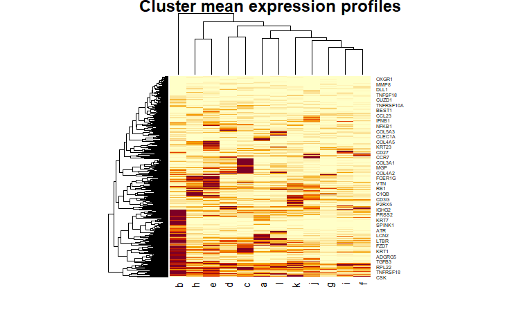

```r
heatmap(sweep(unsup$profiles, 1, pmax(apply(unsup$profiles, 1, max), .2), "/"), scale = "none",
        main = "Cluster mean expression profiles")
```

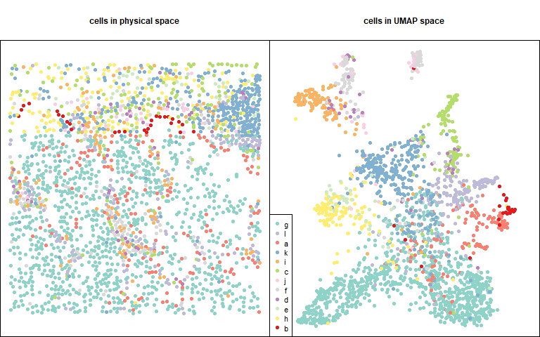

```r
# define cluster colors:
cols <-
  c(
    '#8DD3C7',
    '#BEBADA',
    '#FB8072',
    '#80B1D3',
    '#FDB462',
    '#B3DE69',
    '#FCCDE5',
    '#D9D9D9',
    '#BC80BD',
    '#CCEBC5',
    '#FFED6F',
    '#E41A1C',
    '#377EB8',
    '#4DAF4A',
    '#984EA3',
    '#FF7F00',
    '#FFFF33',
    '#A65628',
    '#F781BF',
    '#999999'
  )
cols <- cols[seq_along(unique(unsup$clust))]
names(cols) <- unique(unsup$clust)

par(mfrow = c(1, 2))
par(mar = c(0, 0, 3, 0))

plot(mini_nsclc$x, mini_nsclc$y, pch = 16, cex = .75, asp = 1, cex.main = 0.75,
          main = "cells in physical space",
     col = cols[unsup$clust], xlab = "", ylab = "", xaxt = "n", yaxt = "n")

plot(mini_nsclc$umap, pch = 16, cex = .75, asp = 1, cex.main = 0.75,
     main = "cells in UMAP space",
     col = cols[unsup$clust], xlab = "", ylab = "", xaxt = "n", yaxt = "n")
legend("bottomleft", pch = 16, col = cols, legend = names(cols), cex = 0.7)
```

```r
# define colors:
cols <-
  c(
    '#8DD3C7',
    '#BEBADA',
    '#FB8072',
    '#80B1D3',
    '#FDB462',
    '#B3DE69',
    '#FCCDE5',
    '#D9D9D9',
    '#BC80BD',
    '#CCEBC5',
    '#FFED6F',
    '#E41A1C',
    '#377EB8',
    '#4DAF4A',
    '#984EA3',
    '#FF7F00',
    '#FFFF33',
    '#A65628',
    '#F781BF',
    '#999999'
  )
cols <- cols[seq_along(unique(unsup$clust))]
names(cols) <- unique(unsup$clust)

# make the flightpath plot
fp <- flightpath_plot(flightpath_result = NULL, insitutype_result = unsup, col = cols[unsup$clust])
class(fp)
```

```
#> [1] "gg"     "ggplot"
```

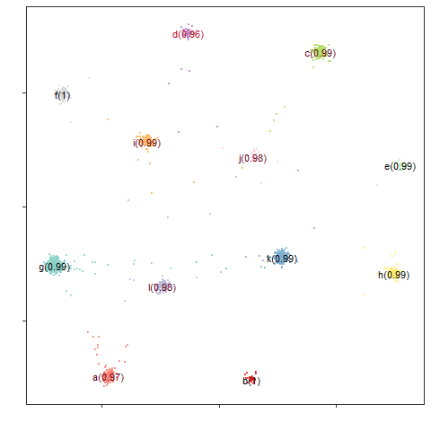

```r
print(fp)
```

In the above plot, a cell atop a cluster centroid is near-certain, while cells halfway between two centroids have 50% posterior probability of belonging to each of those two clusters. The number by each centroid gives the average posterior probability of cells in the cluster. Expect to see this value above 0.9 for clustering major cell type, and above 0.75 when clustering apart closely-related cell types. Clusters with average posterior probabilities are unreliable. You can either interpret them with caution, or you can dissolve them and reassign their cells to other clusters. (The next section covers this operation.)

You can also extract the flightpath layout for plotting on your own:

```r
# compute the flightpath layout:
fp_layout <- flightpath_layout(logliks = unsup$logliks, profiles = unsup$profiles)
str(fp_layout)
```

```
#> List of 4
#>  $ clustpos      : num [1:12, 1:2] -5.93 2.84 3.67 -1.57 7.18 ...
#>   ..- attr(*, "dimnames")=List of 2
#>   .. ..$ : chr [1:12] "a" "b" "c" "d" ...
#>   .. ..$ : chr [1:2] "x" "y"
#>  $ cellpos       : num [1:2198, 1:2] -2.76 -2.88 -3.12 -2.77 -1.91 ...
#>   ..- attr(*, "dimnames")=List of 2
#>   .. ..$ : chr [1:2198] "c_3_18_2" "c_3_18_3" "c_3_18_4" "c_3_18_5" ...
#>   .. ..$ : chr [1:2] "x" "y"
#>  $ clust         : chr [1:2198] "g" "g" "g" "g" ...
#>  $ meanconfidence: Named num [1:12] 0.973 0.999 0.986 0.957 0.993 ...
#>   ..- attr(*, "names")= chr [1:12] "a" "b" "c" "d" ...
```

```r
# plot it:
#par(mar = c(0,0,0,0))
#plot(fp_layout$cellpos, pch = 16, cex = 0.5, col = cols[unsup$clust], xaxt = "n", yaxt = "n", xlab = "", ylab = "")
#text(fp_layout$clustpos, rownames(fp_layout$clustpos), cex = 0.5)
```

#### Updating clustering results

After close review, you might want to update your clustering results.

The function refineCells can modify your results in the following ways:

- merge closely-related or frequently-confused clusters
- delete clusters (Sometimes a “catch-all” cluster arises that is frequently confused wiht multiple other clusters. It is best to delete these clusters and let their cells get reassigned to meaningful clusters.)
- sub-cluster large clusters

Here we use the refineClusters function to perform all these operations. We also use its “merges” argument to rename cluster c.

```r
# refine the clusters:
newclusts <- refineClusters(logliks = unsup$logliks,
                            merges = c("g" = "newcluster", "e" = "newcluster", "c" = "c_renamed"),
                            to_delete = "a",
                            subcluster = c("f" = 2),
                            counts = counts,
                            neg = negmean)
```

```
#> Subclustering f
#> 1.07 cells per geometric bin.
#> phase 1: random starts in 128 cell subsets
#> iter 1
#> iter 2
#> iter 3
#> iter 4
#> Converged: <= 0.2% of cell type assignments changed in the last iteration.
#> ==========================================================================
#> iter 1
#> iter 2
#> iter 3
#> iter 4
#> iter 5
#> Converged: <= 0.2% of cell type assignments changed in the last iteration.
#> ==========================================================================
#> iter 1
#> iter 2
#> iter 3
#> iter 4
#> iter 5
#> iter 6
#> Converged: <= 0.2% of cell type assignments changed in the last iteration.
#> ==========================================================================
#> phase 2: refining best random start in a 128 cell subset
#> iter 1
#> iter 2
#> Converged: <= 0.1% of cell type assignments changed in the last iteration.
#> ==========================================================================
#> phase 3: finalizing clusters in a 128 cell subset
#> iter 1
#> iter 2
#> Converged: <= 0.01% of cell type assignments changed in the last iteration.
#> ==========================================================================
#> phase 4: classifying all 128 cells
```

```r
str(newclusts)
```

```
#> List of 5
#>  $ clust                      : Named chr [1:2198] "newcluster" "newcluster" "newcluster" "newcluster" ...
#>   ..- attr(*, "names")= chr [1:2198] "c_3_18_2" "c_3_18_3" "c_3_18_4" "c_3_18_5" ...
#>  $ prob                       : Named num [1:2198] 1 1 1 1 1 ...
#>   ..- attr(*, "names")= chr [1:2198] "c_3_18_2" "c_3_18_3" "c_3_18_4" "c_3_18_5" ...
#>  $ logliks                    : num [1:2198, 1:11] -93 -99.5 -234.2 -112.9 -301.3 ...
#>   ..- attr(*, "dimnames")=List of 2
#>   .. ..$ : chr [1:2198] "c_3_18_2" "c_3_18_3" "c_3_18_4" "c_3_18_5" ...
#>   .. ..$ : chr [1:11] "newcluster" "c_renamed" "b" "d" ...
#>  $ profiles                   : num [1:960, 1:11] 0 0 0.0322 0.0201 0.0001 ...
#>   ..- attr(*, "dimnames")=List of 2
#>   .. ..$ : chr [1:960] "AATK" "ABL1" "ABL2" "ACE" ...
#>   .. ..$ : chr [1:11] "newcluster" "c_renamed" "b" "d" ...
#>  $ logliks_from_lost_celltypes: num[1:2198, 0 ]
#>   ..- attr(*, "dimnames")=List of 2
#>   .. ..$ : chr [1:2198] "c_3_18_2" "c_3_18_3" "c_3_18_4" "c_3_18_5" ...
#>   .. ..$ : NULL
```

```r
# plot the updated results:
cols <-
  c(
    '#8DD3C7',
    '#BEBADA',
    '#FB8072',
    '#80B1D3',
    '#FDB462',
    '#B3DE69',
    '#FCCDE5',
    '#D9D9D9',
    '#BC80BD',
    '#CCEBC5',
    '#FFED6F',
    '#E41A1C',
    '#377EB8',
    '#4DAF4A',
    '#984EA3',
    '#FF7F00',
    '#FFFF33',
    '#A65628',
    '#F781BF',
    '#999999'
  )
cols <- cols[seq_along(unique(newclusts$clust))]
names(cols) <- unique(newclusts$clust)
fp <- flightpath_plot(flightpath_result = NULL, insitutype_result = newclusts, col = cols[newclusts$clust])
class(fp)
```

```
#> [1] "gg"     "ggplot"
```

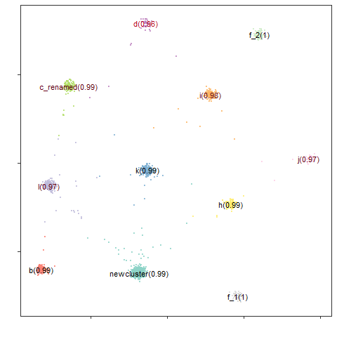

```r
print(fp)
```

### Coloring cell types

The colorCellTypes function attempts to choose good colors for your cell types. Some of its options use the frequency of cell types in this decision. Here are 3 versions:

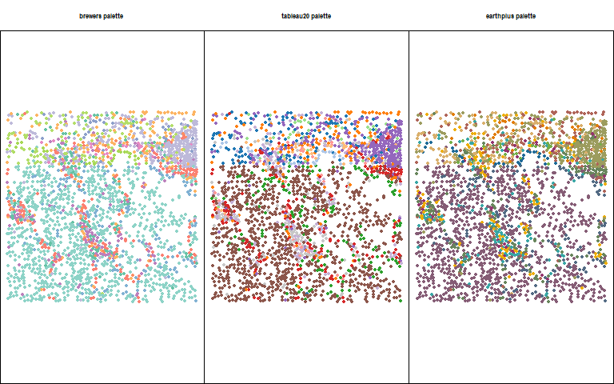

```r
par(mfrow = c(1, 3))
par(mar = c(0, 0, 3, 0))

plot(mini_nsclc$x, mini_nsclc$y, pch = 16, cex = .75, asp = 1, cex.main = 0.75,
          main = "brewers palette",
     col = colorCellTypes(freqs = table(unsup$clust), palette = "brewers")[unsup$clust],
     xlab = "", ylab = "", xaxt = "n", yaxt = "n")

plot(mini_nsclc$x, mini_nsclc$y, pch = 16, cex = .75, asp = 1, cex.main = 0.75,
          main = "tableau20 palette",
     col = colorCellTypes(freqs = table(unsup$clust), palette = "tableau20")[unsup$clust],
     xlab = "", ylab = "", xaxt = "n", yaxt = "n")

plot(mini_nsclc$x, mini_nsclc$y, pch = 16, cex = .75, asp = 1, cex.main = 0.75,
          main = "earthplus palette",
     col = colorCellTypes(freqs = table(unsup$clust), palette = "earthplus")[unsup$clust],
     xlab = "", ylab = "", xaxt = "n", yaxt = "n")
```